# 머신러닝 수행절차

1. 태스크 정의
2. 모델의 성능평가 지표 설정
3. 데이터 수집
4. 데이터 탐색 및 전처리
5. 학습 (훈련데이터)
6. 모델의 성능평가 (시험데이터)

## 태스크 정의:

텔콤의 다양한 데이터를 사용하여 고객의 이탈(Churn)을 Yes/No 로 예측하는 이진분류 태스크

## 모델의 성능평가 지표 설정

- 분류이므로 정확도를 기본 지표로 사용한다.
- Churn이 Yes인데 No로 예측하는 위음성(False Negative)의 케이스를 줄이기 위하여 재현율을 보조적인 지표로 사용한다.
- 정확도의 목표치는 95%로 설정한다.
- 재현율은 모델의 복잡도가 증가함에 따라 높이는 것으로 목표로 한다.

## 데이터 수집

캐글의 공개데이터를 다운로드하여 csv로 저장하여 사용한다.

```python
import pandas as pd
data = pd.read_csv('WA_Fn-UseC_-Telco-Customer-Churn.csv')
```

```python
try:
    totalcharges = map(lambda x: float(x), data.TotalCharges)
except:
    print('except')
```

```python
list(totalcharges)
```

[output not shown]

```python
np.where(data.TotalCharges=='')
```

```
(array([], dtype=int64),)
```

## 데이터 탐색 및 전처리

```python
# 누락값 확인
print('\n## number of null data: ##\n\n', data.isnull().sum())
```

```
## number of null data: ##

 customerID          0
gender              0
SeniorCitizen       0
Partner             0
Dependents          0
tenure              0
PhoneService        0
MultipleLines       0
InternetService     0
OnlineSecurity      0
OnlineBackup        0
DeviceProtection    0
TechSupport         0
StreamingTV         0
StreamingMovies     0
Contract            0
PaperlessBilling    0
PaymentMethod       0
MonthlyCharges      0
TotalCharges        0
Churn               0
dtype: int64
```

```python
# 데이터 탐색
data.info()
```

```
<class 'pandas.core.frame.DataFrame'>
RangeIndex: 7043 entries, 0 to 7042
Data columns (total 21 columns):
 #   Column            Non-Null Count  Dtype
---  ------            --------------  -----
 0   customerID        7043 non-null   object
 1   gender            7043 non-null   object
 2   SeniorCitizen     7043 non-null   int64
 3   Partner           7043 non-null   object
 4   Dependents        7043 non-null   object
 5   tenure            7043 non-null   int64
 6   PhoneService      7043 non-null   object
 7   MultipleLines     7043 non-null   object
 8   InternetService   7043 non-null   object
 9   OnlineSecurity    7043 non-null   object
 10  OnlineBackup      7043 non-null   object
 11  DeviceProtection  7043 non-null   object
 12  TechSupport       7043 non-null   object
 13  StreamingTV       7043 non-null   object
 14  StreamingMovies   7043 non-null   object
 15  Contract          7043 non-null   object
 16  PaperlessBilling  7043 non-null   object
 17  PaymentMethod     7043 non-null   object
 18  MonthlyCharges    7043 non-null   float64
 19  TotalCharges      7043 non-null   object
 20  Churn             7043 non-null   object
dtypes: float64(1), int64(2), object(18)
memory usage: 1.1+ MB
```

수치 데이터의 요약정보 확인

```python
data.describe()
```

|  | SeniorCitizen | tenure | MonthlyCharges |
| --- | --- | --- | --- |
| count | 7043.000000 | 7043.000000 | 7043.000000 |
| mean | 0.162147 | 32.371149 | 64.761692 |
| std | 0.368612 | 24.559481 | 30.090047 |
| min | 0.000000 | 0.000000 | 18.250000 |
| 25% | 0.000000 | 9.000000 | 35.500000 |
| 50% | 0.000000 | 29.000000 | 70.350000 |
| 75% | 0.000000 | 55.000000 | 89.850000 |
| max | 1.000000 | 72.000000 | 118.750000 |

```python
data.SeniorCitizen
```

```
0       0
1       0
2       0
3       0
4       0
       ..
7038    0
7039    0
7040    0
7041    1
7042    0
Name: SeniorCitizen, Length: 7043, dtype: int64
```

SeniorCitizen 열은 실제로는 0 또는 1로 불리언 데이터임

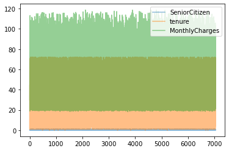

```python
data.plot(alpha=0.5)
```

명목형이나 범주형 데이터의 요약정보 확인

```python
data.columns
```

```
Index(['customerID', 'gender', 'SeniorCitizen', 'Partner', 'Dependents',
       'tenure', 'PhoneService', 'MultipleLines', 'InternetService',
       'OnlineSecurity', 'OnlineBackup', 'DeviceProtection', 'TechSupport',
       'StreamingTV', 'StreamingMovies', 'Contract', 'PaperlessBilling',
       'PaymentMethod', 'MonthlyCharges', 'TotalCharges', 'Churn'],
      dtype='object')
```

```python
data[['customerID', 'gender', 'Partner', 'Dependents',
       'PhoneService', 'MultipleLines', 'InternetService',
       'OnlineSecurity', 'OnlineBackup', 'DeviceProtection', 'TechSupport',
       'StreamingTV', 'StreamingMovies', 'Contract', 'PaperlessBilling',
       'PaymentMethod', 'TotalCharges', 'Churn']].describe()
```

|  | customerID | gender | Partner | Dependents | PhoneService | MultipleLines | InternetService | OnlineSecurity | OnlineBackup | DeviceProtection | TechSupport | StreamingTV | StreamingMovies | Contract | PaperlessBilling | PaymentMethod | TotalCharges | Churn |
| --- | --- | --- | --- | --- | --- | --- | --- | --- | --- | --- | --- | --- | --- | --- | --- | --- | --- | --- |
| count | 7043 | 7043 | 7043 | 7043 | 7043 | 7043 | 7043 | 7043 | 7043 | 7043 | 7043 | 7043 | 7043 | 7043 | 7043 | 7043 | 7043 | 7043 |
| unique | 7043 | 2 | 2 | 2 | 2 | 3 | 3 | 3 | 3 | 3 | 3 | 3 | 3 | 3 | 2 | 4 | 6531 | 2 |
| top | 1023-BQXZE | Male | No | No | Yes | No | Fiber optic | No | No | No | No | No | No | Month-to-month | Yes | Electronic check | 20.2 | No |
| freq | 1 | 3555 | 3641 | 4933 | 6361 | 3390 | 3096 | 3498 | 3088 | 3095 | 3473 | 2810 | 2785 | 3875 | 4171 | 2365 | 11 | 5174 |

TotalCharges 열은 실제로 수치데이터 중 실수 타입임

## 데이터 타입을 지정하여 다시 데이터 수집

```python
np.float*?
```

```python
pd.read_csv?
```

```python
import numpy as np
data = pd.read_csv('WA_Fn-UseC_-Telco-Customer-Churn.csv',
                   index_col=0,
                  dtype={'SeniorCitizen':np.object, 'TotalCharges':np.float64},
                  na_values=' ')
```

```python
data.describe()
```

|  | tenure | MonthlyCharges | TotalCharges |
| --- | --- | --- | --- |
| count | 7043.000000 | 7043.000000 | 7032.000000 |
| mean | 32.371149 | 64.761692 | 2283.300441 |
| std | 24.559481 | 30.090047 | 2266.771362 |
| min | 0.000000 | 18.250000 | 18.800000 |
| 25% | 9.000000 | 35.500000 | 401.450000 |
| 50% | 29.000000 | 70.350000 | 1397.475000 |
| 75% | 55.000000 | 89.850000 | 3794.737500 |
| max | 72.000000 | 118.750000 | 8684.800000 |

```python
data.info()
```

```
<class 'pandas.core.frame.DataFrame'>
Index: 7043 entries, 7590-VHVEG to 3186-AJIEK
Data columns (total 20 columns):
 #   Column            Non-Null Count  Dtype
---  ------            --------------  -----
 0   gender            7043 non-null   object
 1   SeniorCitizen     7043 non-null   object
 2   Partner           7043 non-null   object
 3   Dependents        7043 non-null   object
 4   tenure            7043 non-null   int64
 5   PhoneService      7043 non-null   object
 6   MultipleLines     7043 non-null   object
 7   InternetService   7043 non-null   object
 8   OnlineSecurity    7043 non-null   object
 9   OnlineBackup      7043 non-null   object
 10  DeviceProtection  7043 non-null   object
 11  TechSupport       7043 non-null   object
 12  StreamingTV       7043 non-null   object
 13  StreamingMovies   7043 non-null   object
 14  Contract          7043 non-null   object
 15  PaperlessBilling  7043 non-null   object
 16  PaymentMethod     7043 non-null   object
 17  MonthlyCharges    7043 non-null   float64
 18  TotalCharges      7032 non-null   float64
 19  Churn             7043 non-null   object
dtypes: float64(2), int64(1), object(17)
memory usage: 1.1+ MB
```

```python
data.columns
```

```
Index(['gender', 'SeniorCitizen', 'Partner', 'Dependents', 'tenure',
       'PhoneService', 'MultipleLines', 'InternetService', 'OnlineSecurity',
       'OnlineBackup', 'DeviceProtection', 'TechSupport', 'StreamingTV',
       'StreamingMovies', 'Contract', 'PaperlessBilling', 'PaymentMethod',
       'MonthlyCharges', 'TotalCharges', 'Churn'],
      dtype='object')
```

```python
data.nunique(0)
```

```
gender                 2
SeniorCitizen          2
Partner                2
Dependents             2
tenure                73
PhoneService           2
MultipleLines          3
InternetService        3
OnlineSecurity         3
OnlineBackup           3
DeviceProtection       3
TechSupport            3
StreamingTV            3
StreamingMovies        3
Contract               3
PaperlessBilling       2
PaymentMethod          4
MonthlyCharges      1585
TotalCharges        6530
Churn                  2
dtype: int64
```

```python
data.info()
```

```
<class 'pandas.core.frame.DataFrame'>
Index: 7043 entries, 7590-VHVEG to 3186-AJIEK
Data columns (total 20 columns):
 #   Column            Non-Null Count  Dtype
---  ------            --------------  -----
 0   gender            7043 non-null   object
 1   SeniorCitizen     7043 non-null   object
 2   Partner           7043 non-null   object
 3   Dependents        7043 non-null   object
 4   tenure            7043 non-null   int64
 5   PhoneService      7043 non-null   object
 6   MultipleLines     7043 non-null   object
 7   InternetService   7043 non-null   object
 8   OnlineSecurity    7043 non-null   object
 9   OnlineBackup      7043 non-null   object
 10  DeviceProtection  7043 non-null   object
 11  TechSupport       7043 non-null   object
 12  StreamingTV       7043 non-null   object
 13  StreamingMovies   7043 non-null   object
 14  Contract          7043 non-null   object
 15  PaperlessBilling  7043 non-null   object
 16  PaymentMethod     7043 non-null   object
 17  MonthlyCharges    7043 non-null   float64
 18  TotalCharges      7032 non-null   float64
 19  Churn             7043 non-null   object
dtypes: float64(2), int64(1), object(17)
memory usage: 1.1+ MB
```

```python
data.Churn.value_counts()
```

```
No     5174
Yes    1869
Name: Churn, dtype: int64
```

```python
data.head()
```

| customerID | gender | SeniorCitizen | Partner | Dependents | tenure | PhoneService | MultipleLines | InternetService | OnlineSecurity | OnlineBackup | DeviceProtection | TechSupport | StreamingTV | StreamingMovies | Contract | PaperlessBilling | PaymentMethod | MonthlyCharges | TotalCharges | Churn |
| --- | --- | --- | --- | --- | --- | --- | --- | --- | --- | --- | --- | --- | --- | --- | --- | --- | --- | --- | --- | --- |
| 7590-VHVEG | Female | 0 | Yes | No | 1 | No | No phone service | DSL | No | Yes | No | No | No | No | Month-to-month | Yes | Electronic check | 29.85 | 29.85 | No |
| 5575-GNVDE | Male | 0 | No | No | 34 | Yes | No | DSL | Yes | No | Yes | No | No | No | One year | No | Mailed check | 56.95 | 1889.50 | No |
| 3668-QPYBK | Male | 0 | No | No | 2 | Yes | No | DSL | Yes | Yes | No | No | No | No | Month-to-month | Yes | Mailed check | 53.85 | 108.15 | Yes |
| 7795-CFOCW | Male | 0 | No | No | 45 | No | No phone service | DSL | Yes | No | Yes | Yes | No | No | One year | No | Bank transfer (automatic) | 42.30 | 1840.75 | No |
| 9237-HQITU | Female | 0 | No | No | 2 | Yes | No | Fiber optic | No | No | No | No | No | No | Month-to-month | Yes | Electronic check | 70.70 | 151.65 | Yes |

```python
num_columns = data.describe(include=[numpy.float64, numpy.int64]).columns
num_columns
```

```
Index(['tenure', 'MonthlyCharges', 'TotalCharges'], dtype='object')
```

```python
data.describe(exclude=[numpy.float64, numpy.int64])
```

|  | gender | SeniorCitizen | Partner | Dependents | PhoneService | MultipleLines | InternetService | OnlineSecurity | OnlineBackup | DeviceProtection | TechSupport | StreamingTV | StreamingMovies | Contract | PaperlessBilling | PaymentMethod | Churn |
| --- | --- | --- | --- | --- | --- | --- | --- | --- | --- | --- | --- | --- | --- | --- | --- | --- | --- |
| count | 7043 | 7043 | 7043 | 7043 | 7043 | 7043 | 7043 | 7043 | 7043 | 7043 | 7043 | 7043 | 7043 | 7043 | 7043 | 7043 | 7043 |
| unique | 2 | 2 | 2 | 2 | 2 | 3 | 3 | 3 | 3 | 3 | 3 | 3 | 3 | 3 | 2 | 4 | 2 |
| top | Male | 0 | No | No | Yes | No | Fiber optic | No | No | No | No | No | No | Month-to-month | Yes | Electronic check | No |
| freq | 3555 | 5901 | 3641 | 4933 | 6361 | 3390 | 3096 | 3498 | 3088 | 3095 | 3473 | 2810 | 2785 | 3875 | 4171 | 2365 | 5174 |

```python
cat_columns = data.describe(exclude=[numpy.float64, numpy.int64]).columns
cat_columns
```

```
Index(['gender', 'SeniorCitizen', 'Partner', 'Dependents', 'PhoneService',
       'MultipleLines', 'InternetService', 'OnlineSecurity', 'OnlineBackup',
       'DeviceProtection', 'TechSupport', 'StreamingTV', 'StreamingMovies',
       'Contract', 'PaperlessBilling', 'PaymentMethod', 'Churn'],
      dtype='object')
```

```python
for col in cat_columns:
    print('\n[%s]'%col)
    print(data[col].value_counts())
```

```
[gender]
Male      3555
Female    3488
Name: gender, dtype: int64

[SeniorCitizen]
0    5901
1    1142
Name: SeniorCitizen, dtype: int64

[Partner]
No     3641
Yes    3402
Name: Partner, dtype: int64

[Dependents]
No     4933
Yes    2110
Name: Dependents, dtype: int64

[PhoneService]
Yes    6361
No      682
Name: PhoneService, dtype: int64

[MultipleLines]
No                  3390
Yes                 2971
No phone service     682
Name: MultipleLines, dtype: int64

[InternetService]
Fiber optic    3096
DSL            2421
No             1526
Name: InternetService, dtype: int64

[OnlineSecurity]
No                     3498
Yes                    2019
```

[output cut: 40 more lines]

```
Yes    4171
No     2872
Name: PaperlessBilling, dtype: int64

[PaymentMethod]
Electronic check             2365
Mailed check                 1612
Bank transfer (automatic)    1544
Credit card (automatic)      1522
Name: PaymentMethod, dtype: int64

[Churn]
No     5174
Yes    1869
Name: Churn, dtype: int64
```

### 수치형 데이터 전처리 파이프라인

```python
data[num_columns]
```

| customerID | tenure | MonthlyCharges | TotalCharges |
| --- | --- | --- | --- |
| 7590-VHVEG | 1 | 29.85 | 29.85 |
| 5575-GNVDE | 34 | 56.95 | 1889.50 |
| 3668-QPYBK | 2 | 53.85 | 108.15 |
| 7795-CFOCW | 45 | 42.30 | 1840.75 |
| 9237-HQITU | 2 | 70.70 | 151.65 |
| ... | ... | ... | ... |
| 6840-RESVB | 24 | 84.80 | 1990.50 |
| 2234-XADUH | 72 | 103.20 | 7362.90 |
| 4801-JZAZL | 11 | 29.60 | 346.45 |
| 8361-LTMKD | 4 | 74.40 | 306.60 |
| 3186-AJIEK | 66 | 105.65 | 6844.50 |

7043 rows × 3 columns

```python
from sklearn.base import BaseEstimator, TransformerMixin
import pandas as pd

class DataFrameSelector(BaseEstimator, TransformerMixin):
    def __init__(self, column_list):
        self.column_list = column_list

    def fit(self, X, y=None):
        return self

    def transform(self, X, y=None):
        return pd.DataFrame(X[self.column_list], columns=self.column_list)

class myDataFrameTransformer(BaseEstimator, TransformerMixin):
    def __init__(self, columnlist=None, index=None):
        self.columnlist = columnlist
        self.index = index

    def fit(self, X, y=None):
        return self

    def transform(self, X, y=None):
        return pd.DataFrame(X, columns=self.columnlist, index=self.index)

class myOneHotEncoder(BaseEstimator, TransformerMixin):
    def __init__(self):
        pass

    def fit(self, X, y=None):
        return self

    def transform(self, X, y=None):
        return pd.get_dummies(X)
```

```python
from sklearn.pipeline import Pipeline, FeatureUnion
from sklearn.compose import ColumnTransformer
from sklearn.preprocessing import StandardScaler, MinMaxScaler, OneHotEncoder
from sklearn.impute import SimpleImputer

num_pipe = Pipeline([
    ('selector', DataFrameSelector(num_columns)),
    # ('imputer', SimpleImputer(fill_value=0.0)),
    ('imputer', SimpleImputer(strategy='median')),
    ('scaler', StandardScaler()),
    ('dftransformer', myDataFrameTransformer(columnlist=num_columns, index=data.index))
])
cat_pipe = Pipeline([
    ('selector', DataFrameSelector(cat_columns[:-1])), # 범주형 중 Churn 컬럼을 제외
    # ('encoder', OneHotEncoder(handle_unknown='ignore', sparse=False))
    ('encoder', myOneHotEncoder())
])
featureunion = FeatureUnion([('num_data', num_pipe),
                             ('cat_data', cat_pipe)])
```

```python
num_data = num_pipe.fit_transform(data)
num_data[:2]
```

| customerID | tenure | MonthlyCharges | TotalCharges |
| --- | --- | --- | --- |
| 7590-VHVEG | -1.277445 | -1.160323 | -0.994242 |
| 5575-GNVDE | 0.066327 | -0.259629 | -0.173244 |

### 범주형 데이터 전처리 파이프라인

```python
data.info()
```

[output not shown]

```python
cat_data = cat_pipe.fit_transform(data)
```

```python
cat_data[:2]
```

| customerID | gender_Female | gender_Male | SeniorCitizen_0 | SeniorCitizen_1 | Partner_No | Partner_Yes | Dependents_No | Dependents_Yes | PhoneService_No | PhoneService_Yes | ... | StreamingMovies_Yes | Contract_Month-to-month | Contract_One year | Contract_Two year | PaperlessBilling_No | PaperlessBilling_Yes | PaymentMethod_Bank transfer (automatic) | PaymentMethod_Credit card (automatic) | PaymentMethod_Electronic check | PaymentMethod_Mailed check |
| --- | --- | --- | --- | --- | --- | --- | --- | --- | --- | --- | --- | --- | --- | --- | --- | --- | --- | --- | --- | --- | --- |
| 7590-VHVEG | 1 | 0 | 1 | 0 | 0 | 1 | 1 | 0 | 1 | 0 | ... | 0 | 1 | 0 | 0 | 0 | 1 | 0 | 0 | 1 | 0 |
| 5575-GNVDE | 0 | 1 | 1 | 0 | 1 | 0 | 1 | 0 | 0 | 1 | ... | 0 | 0 | 1 | 0 | 1 | 0 | 0 | 0 | 0 | 1 |

2 rows × 43 columns

### 수치형과 범주형 데이터를 각각의 파이프라인으로 전처리 후 연결해주는 FeatureUnion의 적용

```python
X = featureunion.fit_transform(data)
```

```python
X[:2]
```

```
array([[-1.27744458, -1.16032292, -0.99424194,  1.        ,  0.        ,
         1.        ,  0.        ,  0.        ,  1.        ,  1.        ,
         0.        ,  1.        ,  0.        ,  0.        ,  1.        ,
         0.        ,  1.        ,  0.        ,  0.        ,  1.        ,
         0.        ,  0.        ,  0.        ,  0.        ,  1.        ,
         1.        ,  0.        ,  0.        ,  1.        ,  0.        ,
         0.        ,  1.        ,  0.        ,  0.        ,  1.        ,
         0.        ,  0.        ,  1.        ,  0.        ,  0.        ,
         0.        ,  1.        ,  0.        ,  0.        ,  1.        ,
         0.        ],
       [ 0.06632742, -0.25962894, -0.17324413,  0.        ,  1.        ,
         1.        ,  0.        ,  1.        ,  0.        ,  1.        ,
         0.        ,  0.        ,  1.        ,  1.        ,  0.        ,
         0.        ,  1.        ,  0.        ,  0.        ,  0.        ,
         0.        ,  1.        ,  1.        ,  0.        ,  0.        ,
         0.        ,  0.        ,  1.        ,  1.        ,  0.        ,
         0.        ,  1.        ,  0.        ,  0.        ,  1.        ,
         0.        ,  0.        ,  0.        ,  1.        ,  0.        ,
         1.        ,  0.        ,  0.        ,  0.        ,  0.        ,
         1.        ]])
```

```python
num_data.columns
```

```
Index(['tenure', 'MonthlyCharges', 'TotalCharges'], dtype='object')
```

```python
cat_data.columns
```

```
Index(['gender_Female', 'gender_Male', 'SeniorCitizen_0', 'SeniorCitizen_1',
       'Partner_No', 'Partner_Yes', 'Dependents_No', 'Dependents_Yes',
       'PhoneService_No', 'PhoneService_Yes', 'MultipleLines_No',
       'MultipleLines_No phone service', 'MultipleLines_Yes',
       'InternetService_DSL', 'InternetService_Fiber optic',
       'InternetService_No', 'OnlineSecurity_No',
       'OnlineSecurity_No internet service', 'OnlineSecurity_Yes',
       'OnlineBackup_No', 'OnlineBackup_No internet service',
       'OnlineBackup_Yes', 'DeviceProtection_No',
       'DeviceProtection_No internet service', 'DeviceProtection_Yes',
       'TechSupport_No', 'TechSupport_No internet service', 'TechSupport_Yes',
       'StreamingTV_No', 'StreamingTV_No internet service', 'StreamingTV_Yes',
       'StreamingMovies_No', 'StreamingMovies_No internet service',
       'StreamingMovies_Yes', 'Contract_Month-to-month', 'Contract_One year',
       'Contract_Two year', 'PaperlessBilling_No', 'PaperlessBilling_Yes',
       'PaymentMethod_Bank transfer (automatic)',
       'PaymentMethod_Credit card (automatic)',
       'PaymentMethod_Electronic check', 'PaymentMethod_Mailed check'],
      dtype='object')
```

```python
feature_names = list(num_data.columns) + list(cat_data.columns)
len(feature_names)
```

```
46
```

```python
data.shape
```

```
(7043, 20)
```

```python
X.shape
```

```
(7043, 46)
```

```python
y = data['Churn'].values
```

```python
X.shape
```

```
(7043, 46)
```

```python
y.shape
```

```
(7043,)
```

### 훈련데이터와 시험데이터 나누기

```python
from sklearn.model_selection import train_test_split
X_train, X_test, y_train, y_test = train_test_split(X, y, test_size=0.2, random_state=3, stratify=y)
```

## 학습 (훈련데이터)

```python
from sklearn.neighbors import KNeighborsClassifier
knn_clf = KNeighborsClassifier(n_neighbors=3)
knn_clf.fit(X_train, y_train)
```

## 모델의 성능평가 (시험데이터)

```python
knn_clf.score(X_test, y_test)
```

```
0.7508871540099361
```

```python
X.shape
```

```
(7043, 46)
```

```python
scores = []
for k in range(2, 200, 5):
    knn_clf = KNeighborsClassifier(n_neighbors=k)
    knn_clf.fit(X_train, y_train)
    scores.append(knn_clf.score(X_test, y_test))
```

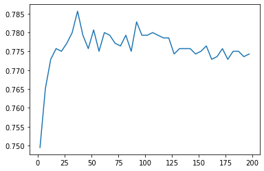

```python
import matplotlib.pyplot as plt
fig, ax = plt.subplots(1, 1)
ax.plot(range(2, 200, 5), scores)
```

```python
knn_clf = KNeighborsClassifier(n_neighbors=35)
scores = []

from sklearn.model_selection import StratifiedKFold
skf = StratifiedKFold(n_splits=5, shuffle=True, random_state=3)
print(skf)
for train_index, test_index in skf.split(X, y):
    # print("TRAIN:", train_index, "TEST:", test_index)
    X_train, X_test = X[train_index], X[test_index]
    y_train, y_test = y[train_index], y[test_index]
    knn_clf.fit(X_train, y_train)
    scores.append(knn_clf.score(X_test, y_test))
print(scores)
print('average score of %d subsets: %.2f' % (skf.n_splits, np.array(scores).mean()))
```

```
StratifiedKFold(n_splits=5, random_state=3, shuffle=True)
[0.7955997161107168, 0.7806955287437899, 0.8041163946061036, 0.7940340909090909, 0.7911931818181818]
average score of 5 subsets: 0.79
```

```python
# from sklearn.linear_model import LogisticRegression
log_clf = LogisticRegression(penalty='l1', C=0.9, solver='liblinear', max_iter=1000, tol=0.0000001)
log_clf.fit(X_train, y_train)
log_clf.score(X_test, y_test)
```

```
0.7840909090909091
```

```python
log_clf.intercept_
```

```
array([-6.03741176e-10])
```

```python
log_clf.coef_
```

```
array([[-1.23072326,  0.65436153,  0.4794488 ,  0.        , -0.03910515,
        -0.22055173,  0.        ,  0.        , -0.03220689,  0.        ,
        -0.15319389,  0.        , -0.83636259, -0.1858362 ,  0.        ,
         0.        , -0.21507996,  0.        ,  0.        ,  0.12259268,
        -0.06668185, -0.39374487,  0.01600279,  0.        , -0.29099297,
         0.00990732,  0.        , -0.13998166,  0.29684527,  0.        ,
        -0.27161606,  0.        ,  0.        ,  0.        ,  0.        ,
         0.        ,  0.        ,  0.13987893, -0.55623527, -1.16606369,
        -0.35575355,  0.        , -0.03082946, -0.07480395,  0.33142593,
         0.        ]])
```

```python
log_clf.coef_.argsort()[0][-3:]
```

```
array([44,  2,  1], dtype=int64)
```

```python
np.array(feature_names)[log_clf.coef_.argsort()[0][-3:]]
```

```
array(['PaymentMethod_Electronic check', 'TotalCharges', 'MonthlyCharges'],
      dtype='<U39')
```

```python
log_clf.coef_.argsort()[0][:3]
```

```
array([ 0, 39, 12], dtype=int64)
```

```python
np.array(feature_names)[log_clf.coef_.argsort()[0][:3]]
```

```
array(['tenure', 'Contract_Two year', 'PhoneService_Yes'], dtype='<U39')
```

```python
LogisticRegression?
```

```python
LogisticRegression?
```

```python
from sklearn.tree import DecisionTreeClassifier
tree_clf = DecisionTreeClassifier(criterion='gini')
tree_clf.fit(X_train, y_train)
tree_clf.score(X_test, y_test)
```

```
0.7159090909090909
```

```python
tree_clf?
```

```python
from sklearn.svm import SVC
svm_clf = SVC(tol=0.00001)
svm_clf.fit(X_train, y_train)
```

```python
svm_clf.score(X_test, y_test)
```

```
0.7919034090909091
```

```python
from sklearn.model_selection import RandomizedSearchCV
randomCV = RandomizedSearchCV(tree_clf,
                              {'criterion':['gini', 'entropy'], 'max_depth':[10, 15]},
                              n_iter=3,
                              scoring='accuracy',
                              n_jobs=-1,
                              refit=True,
                              cv=5,
                              verbose=0,
                              pre_dispatch='2*n_jobs',
                              random_state=None,
                              error_score=nan,
                              return_train_score=True)
randomCV.fit(X, y)
```

```python
randomCV.best_score_
```

```
0.7701258952190464
```

```python
randomCV.best_estimator_
```

```python
randomCV.cv_results_
```

```
{'mean_fit_time': array([0.10870571, 0.12705975, 0.10591626]),
 'std_fit_time': array([0.01649751, 0.03007013, 0.01861979]),
 'mean_score_time': array([0.0173543 , 0.0065824 , 0.00578513]),
 'std_score_time': array([0.01422514, 0.0022394 , 0.00097765]),
 'param_max_depth': masked_array(data=[15, 10, 10],
              mask=[False, False, False],
        fill_value='?',
             dtype=object),
 'param_criterion': masked_array(data=['gini', 'entropy', 'gini'],
              mask=[False, False, False],
        fill_value='?',
             dtype=object),
 'params': [{'max_depth': 15, 'criterion': 'gini'},
  {'max_depth': 10, 'criterion': 'entropy'},
  {'max_depth': 10, 'criterion': 'gini'}],
 'split0_test_score': array([0.73243435, 0.78069553, 0.76508162]),
 'split1_test_score': array([0.74591909, 0.77146913, 0.76792051]),
 'split2_test_score': array([0.71753016, 0.761533  , 0.74662881]),
 'split3_test_score': array([0.7109375 , 0.76207386, 0.75142045]),
 'split4_test_score': array([0.73934659, 0.77485795, 0.77130682]),
 'mean_test_score': array([0.72923354, 0.7701259 , 0.76047164]),
 'std_test_score': array([0.013135  , 0.00741063, 0.00967147]),
 'rank_test_score': array([3, 1, 2]),
 'split0_train_score': array([0.97195598, 0.85924743, 0.87628683]),
 'split1_train_score': array([0.95296415, 0.85516507, 0.87309194]),
 'split2_train_score': array([0.97319844, 0.87007455, 0.88462904]),
 'split3_train_score': array([0.97284827, 0.86548358, 0.87737356]),
 'split4_train_score': array([0.96557232, 0.86512866, 0.87701863]),
 'mean_train_score': array([0.96730783, 0.86301986, 0.87768   ]),
 'std_train_score': array([0.00769096, 0.00521947, 0.00378977])}
```

```python
randomCV.score(X, y)
```

```
0.8577310805054664
```

```python
randomCV.score(X_test, y_test)
```

```
0.8494318181818182
```

```python
randomCV.best_estimator_
```